# Solutions to Applied Predictive Modeling (Kuhn and Johnson, 2013)

Chapter 6 - Exercise 6.1

by Brian Hassett

# Exercise Instructions

*Instructions adapted from Kuhn and Johnson (2013)[^1].*

Infrared (IR) spectroscopy technology is used to determine the chemical makeup of a substance. The theory of IR spectroscopy holds that unique molecular structures absorb IR frequencies differently. In practice a spectrometer fires a series of IR frequencies into a sample material, and the device measures the absorbance of the sample at each individual frequency. This series of measurements creates a spectrum profile which can then be used to determine the chemical makeup of the sample material. A Tecator Infratec Food and Feed Analyzer instrument was used to analyze 215 samples of meat across 100 frequencies. A sample of these frequency profiles is displayed in Fig. 6.20. In addition to an IR profile, analytical chemistry determined the percent content of water, fat, and protein for each sample. If we can establish a predictive relationship between IR spectrum and fat content, then food scientists could predict a sample’s fat content with IR instead of using analytical chemistry. This would provide costs savings, since analytical chemistry is a more expensive, time-consuming process:

1. The matrix `absorp` contains the 100 absorbance values for the 215 samples, while matrix `endpoints` contains the percent of moisture, fat, and protein in columns 1–3, respectively. Start R and use these commands to load the data:

`> library(caret)`  
`> data(tecator)`

2. In this example the predictors are the measurements at the individual frequencies. Because the frequencies lie in a systematic order (850–1,050 nm), the predictors have a high degree of correlation. Hence, the data lie in a smaller dimension than the total number of predictors (215). Use PCA to determine the effective dimension of these data. What is the effective dimension?
3. Split the data into a training and a test set, pre-process the data, and build each variety of models described in this chapter. For those models with tuning parameters, what are the optimal values of the tuning parameter(s)?
4. Which model has the best predictive ability? Is any model significantly better or worse than the others?
5. Explain which model you would use for predicting the fat content of a sample.

# Setup

```r
# Packages
library(AppliedPredictiveModeling)
library(caret)
library(tidyverse)
library(tidymodels)
library(patchwork)
library(ggcorrplot)

# Load my functions:
source("/home/brian/R/dir/Util/bh_functions.R")

# Options:
theme_set(theme_bw())
options(digits = 4)
```

# (a)

## Load Data

```r
data(tecator)
dim(absorp)
```

```
[1] 215 100
```

```r
dim(endpoints)
```

```
[1] 215   3
```

## Recreate Fig. 6.20

Recreate Fig. 6.20 on page 137:

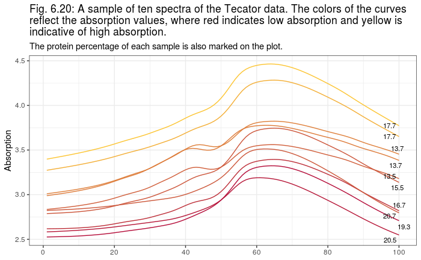

```r
# cbind() the two data frames and then pivot:
abs_data <- data.frame(endpoints) %>%
  set_names(c("moisture", "fat", "protein")) %>%
  mutate(id = 1:nrow(endpoints)) %>% # the id groups the samples
  dplyr::select(id, everything()) %>%
  cbind(data.frame(absorp)) %>%
  slice_head(n = 10) %>% # take a sample of 10
  pivot_longer(X1:X100) %>%
  mutate(index =  as.double(str_replace(name, "X", ""))) %>% # index is the x-axis variable
  dplyr::select(id, index, value, moisture:protein) %>%
  group_by(id) %>%
  mutate(col = min(value)) %>% # Use the max value to color the lines
  ungroup()

abs_data %>%
  ggplot(aes(index, value, group = id, color = col)) + # could be any of the three measurements moisture, fat, protein
  geom_line(show.legend = FALSE) +
  ggrepel::geom_text_repel(data = filter(abs_data, index == 100),
            aes(index, value, label = protein),
            color = "black", hjust = 0, size = 3) +
  scale_color_gradient(low = "#B40B38", high = "#FCC431") +
  scale_x_continuous(breaks = seq(0, 100, by = 20)) +
  labs(x = NULL, y = "Absorption",
       title = str_wrap("Fig. 6.20: A sample of ten spectra of the Tecator data. The colors of the curves reflect the absorption values, where red indicates low absorption and yellow is indicative of high absorption.", 80),
       subtitle = "The protein percentage of each sample is also marked on the plot.")
```

# (b)

## PCA

Conduct a PCA analysis and produce a scree plot:

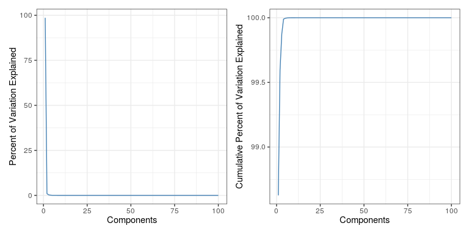

```r
pr <- prcomp(absorp, center = TRUE, scale. = TRUE)
mcomp <- length(pr$sdev)
pve <- 100*(pr$sdev)^2 / sum((pr$sdev)^2)
cum_pve <- cumsum(pve) # add a cumulative PoVE plot

df <- tibble(
  m = 1:mcomp,
  pve,
  cum_pve
)

p1 <- ggplot(df, aes(m, pve)) +
  geom_line(color = "steelblue") +
  labs(x = "Components", y = "Percent of Variation Explained")

p2 <- ggplot(df, aes(m, cum_pve)) +
  geom_line(color = "steelblue") +
  labs(x = "Components", y = "Cumulative Percent of Variation Explained")

p1 + p2
```

Zoom in on the elbow:

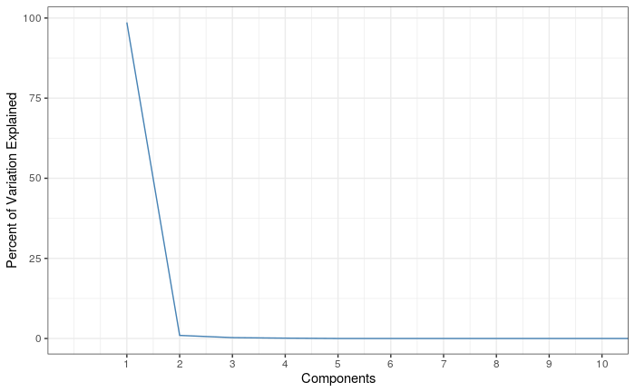

```r
p1 +
  coord_cartesian(xlim = c(0, 10)) +
  scale_x_continuous(breaks = 1:10)
```

The scree plot seems to show that most of the variance is capture by the first component.

Examining a table of the components and corresponding PVE values confirms this:

```r
data.frame(comp = 1:mcomp, pve = format(round(pve, 3), scientific = F)) %>% head(5)
```

|  | comp | pve |
| --- | --- | --- |
| 1 | 1 | 98.626 |
| 2 | 2 | 0.970 |
| 3 | 3 | 0.279 |
| 4 | 4 | 0.114 |
| 5 | 5 | 0.006 |

This indicates that the first components accounts for almost all of the information in the data. Based on this analysis, the true dimensionality is much lower than the number of predictors. However, this is based on a linear combination of the data; other nonlinear summarizations of the predictors may also be useful.

# (c)

For modeling purposes we will treat the `protein` variable as the response.

## Data splitting and resampling using `rsample`

```r
# Load data:
data(tecator)

# Combine the outcome and predictor data sets:
df1 <- data.frame(endpoints) %>%
  set_names(c("moisture", "fat", "protein")) %>%
  dplyr::select(y = protein) %>% # rename the outcome variable `protein` to `y`
  cbind(data.frame(absorp))

# Split data:
set.seed(1)
splits <- initial_split(df1, prop = 3/4) # 75%/25% split for the training and test sets
df_train <- training(splits)
df_test <- testing((splits))

# Create folds for 10-fold cross-validation:
folds <- vfold_cv(df_train, v = 10)
```

## Linear Regression

### Training Data

Build a linear regression model and evaluate using cross-validation:

```r
# Recipe:
rec1 <-
  recipe(y ~ ., data = df_train)

# Model:
lm_mod <-
  linear_reg() %>%
  set_engine("lm")

# Workflow:
workflow1 <-
  workflow() %>%
  add_model(spec = lm_mod) %>%
  add_recipe(recipe = rec1)

# Use `tune::fit_resamples()` to combine the workflow and CV folds to fit the model on the training data:
## Read in cached results if available:
file1 <- "/home/brian/R/dir/APM/chapter6/models/lm_fit_6.1.RDS"
if (file.exists(file1)) {
  lm_fit <- readRDS(file1)
} else {
  lm_fit <-
    workflow1 %>%
    fit_resamples(folds)
  saveRDS(lm_fit, file1)
}
```

View metrics and store the training error:

```r
collect_metrics(lm_fit)
```

| .metric | .estimator | mean | n | std_err | .config |
| --- | --- | --- | --- | --- | --- |
| rmse | standard | 1.0786 | 10 | 0.09948 | Preprocessor1_Model1 |
| rsq | standard | 0.8814 | 10 | 0.01875 | Preprocessor1_Model1 |

```r
rmse_train <- lm_fit %>%
  collect_metrics() %>%
  filter(.metric == "rmse") %>%
  pluck("mean", 1)
```

### Testing Data

Fit a model using all of the training data and apply it to the test data:

```r
# Final fit:
lm_fit_final <-
  workflow1 %>%
  last_fit(splits)

rmse_test <- lm_fit_final %>%
  collect_metrics() %>%
  filter(.metric == "rmse") %>%
  pluck(".estimate", 1)
```

Store the training and test RMSE values and parameters:

```r
RMSE_TM <- tibble(
  framework = "tidymodels",
  engine = "lm",
  model = "Linear Regression",
  rmse_train = rmse_train,
  rmse_test = rmse_test,
  parameters = NA_character_)
```

### Use the predictions to make diagnostic plots

Collect the predictions from the final fit and make diagnostic plots:

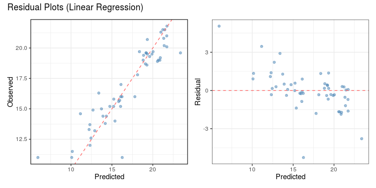

```r
preds <- lm_fit_final %>%
  collect_predictions() %>%
  mutate(residual = y - .pred)

p1 <- ggplot(preds) +
  geom_point(aes(.pred, y),
             color = "steelblue", alpha = 0.5) +
  geom_abline(color = "indianred1", linetype = "dashed") +
  labs(x = "Predicted", y = "Observed")

p2 <- ggplot(preds) +
  geom_point(aes(.pred, residual),
             color = "steelblue", alpha = 0.5) +
  geom_hline(yintercept = 0,
             color = "indianred1", linetype = "dashed") +
  labs(x = "Predicted", y = "Residual")

p1 + p2 + plot_annotation(title = "Residual Plots (Linear Regression)")
```

There seems to be a pattern in the residual plot. The model’s lower predictions tend to be under-predictions and the higher predictions tend be over-predictions.

## Principal Components Regression

### Training Data

Build a linear regression model and evaluate using cross-validation:

```r
# Recipe:
pc_comps <- 25 # fix the number of components for now
rec6 <-
  recipe(y ~ ., data = df_train) %>%
  step_pca(all_predictors(), num_comp = pc_comps)

# Model:
pcr_mod <-
  linear_reg() %>%
  set_engine("lm")

# Workflow:
workflow6 <-
  workflow() %>%
  add_model(spec = pcr_mod) %>%
  add_recipe(recipe = rec6)

# Use `tune::fit_resamples()` to combine the workflow and CV folds to fit the model on the training data:
## Read in cached results if available:
file1 <- "/home/brian/R/dir/APM/chapter6/models/pcr_fit_6.1.RDS"
if (file.exists(file1)) {
  pcr_fit <- readRDS(file1)
} else {
  pcr_fit <-
    workflow6 %>%
    fit_resamples(folds)
  saveRDS(pcr_fit, file1)
}
```

View metrics and store the training error:

```r
collect_metrics(pcr_fit)
```

| .metric | .estimator | mean | n | std_err | .config |
| --- | --- | --- | --- | --- | --- |
| rmse | standard | 0.7542 | 10 | 0.08261 | Preprocessor1_Model1 |
| rsq | standard | 0.9333 | 10 | 0.01293 | Preprocessor1_Model1 |

```r
rmse_train <- pcr_fit %>%
  collect_metrics() %>%
  filter(.metric == "rmse") %>%
  pluck("mean", 1)
```

### Testing Data

Fit a model using all of the training data and apply it to the test data:

```r
# Final fit:
pcr_fit_final <-
  workflow6 %>%
  last_fit(splits)

rmse_test <- pcr_fit_final %>%
  collect_metrics() %>%
  filter(.metric == "rmse") %>%
  pluck(".estimate", 1)
```

Store the training and test RMSE values and parameters:

```r
RMSE_TM <- rbind(RMSE_TM,
                 c(framework = "tidymodels",
                   engine = "lm",
                   model = "PCR",
                   rmse_train = rmse_train,
                   rmse_test = rmse_test,
                   parameters = str_interp("num_comp: ${pc_comps}")))
```

### Use the predictions to make diagnostic plots

Collect the predictions from the final fit and make diagnostic plots:

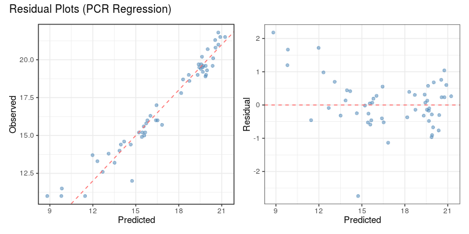

```r
preds <- pcr_fit_final %>%
  collect_predictions() %>%
  mutate(residual = y - .pred)

p11 <- ggplot(preds) +
  geom_point(aes(.pred, y),
             color = "steelblue", alpha = 0.5) +
  geom_abline(color = "indianred1", linetype = "dashed") +
  labs(x = "Predicted", y = "Observed")

p12 <- ggplot(preds) +
  geom_point(aes(.pred, residual),
             color = "steelblue", alpha = 0.5) +
  geom_hline(yintercept = 0,
             color = "indianred1", linetype = "dashed") +
  labs(x = "Predicted", y = "Residual")

p11 + p12 + plot_annotation(title = "Residual Plots (PCR Regression)")
```

## Partial Least Squares

### Training Data

Build a PLS model and train using cross-validation. We will add centering and scaling of the predictors to the preprocessing step:

```r
# Recipe:
rec2 <-
  recipe(y ~ ., data = df_train) %>%
  step_center(all_predictors()) %>%
  step_scale(all_predictors())

# Model:
pls_mod <-
  plsmod::pls(num_comp = tune(), predictor_prop = 1) %>% # 1 = use all predictors
  set_mode("regression") %>%
  set_engine("mixOmics")

# Workflow:
workflow2 <-
  workflow() %>%
  add_model(spec = pls_mod) %>%
  add_recipe(recipe = rec2)

# Tuning grid:
# We saw that the first PC explanined 99% of the variance, but we will tune over a number of components for the PLS model.
pls_grid <- tibble(num_comp = 1:25)

# Use `tune::tune_grid()` to combine the workflow and CV folds to fit the model on the training data:
## Read in cached results if available:
file1 <- "/home/brian/R/dir/APM/chapter6/models/pls_cv_6.1.RDS"
if (file.exists(file1)) {
  pls_cv <- readRDS(file1)
} else {
  pls_cv <-
    workflow2 %>%
    tune_grid(resamples = folds,
              grid = pls_grid,
              control = control_grid(save_pred = TRUE),
              metrics = metric_set(rmse, rsq))
  saveRDS(pls_cv, file1)
}
```

Plot CV results:

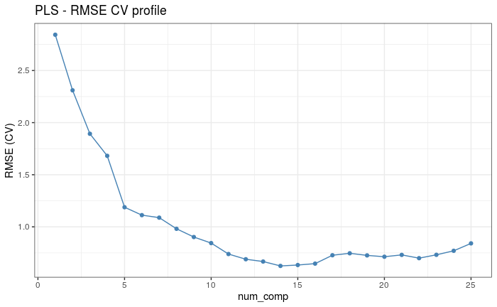

```r
pls_cv %>%
  collect_metrics() %>%
  filter(.metric == "rmse") %>%
  ggplot(aes(num_comp, mean)) +
  geom_point(color = "steelblue") +
  geom_line(color = "steelblue") +
  labs(y = "RMSE (CV)", title = "PLS - RMSE CV profile")
```

Select the best model and store the training error:

```r
pls_best <- pls_cv %>%
  select_best("rmse")

# Store the training error:
rmse_train <- pls_cv %>%
  show_best("rmse") %>%
  pluck("mean", 1)
```

### Testing Data

Fit a model using all of the training data and apply it to the test data:

```r
# Finalize the workflow by updating it to use the best model:
final_wf <-
  workflow2 %>%
  finalize_workflow(pls_best)

# This extracts the parameters in the final model (this code is clunky, could probably be made simpler):
wf <- final_wf %>% workflows::pull_workflow_spec()
num_comp <- wf$args$num_comp[2] %>% as.character()

# Fit the final model using all of the training data and evaluate using the test data:
pls_fit_final <-
  final_wf %>%
  last_fit(splits)

# Store test error:
rmse_test <- pls_fit_final %>%
  collect_metrics() %>%
  filter(.metric == "rmse") %>%
  pluck(".estimate")
```

Store the training and test RMSE values and parameters:

```r
RMSE_TM <- rbind(RMSE_TM,
                 c(framework = "tidymodels",
                   engine = "mixOmics",
                   model = "PLS",
                   rmse_train = rmse_train,
                   rmse_test = rmse_test,
                   parameters = str_interp("num_comp: ${num_comp}")))
```

### Variable importance plot

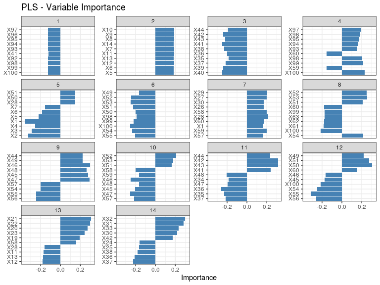

```r
tidy_pls <- fit(final_wf, df_train) %>%
  pull_workflow_fit() %>%
  tidy()

tidy_pls %>%
  filter(term != 'Y') %>%
  group_by(component) %>%
  slice_max(abs(value), n = 10) %>%
  ungroup() %>%
  ggplot(aes(value, fct_reorder(term, value))) +
  geom_col(fill = "steelblue", show.legend = FALSE) +
  facet_wrap(~ component, scales = "free_y") +
  labs(x = "Importance", y = NULL, title = "PLS - Variable Importance")
```

```r
# Ref: https://stackoverflow.com/a/64433792
```

### Use the predictions to make diagnostic plots

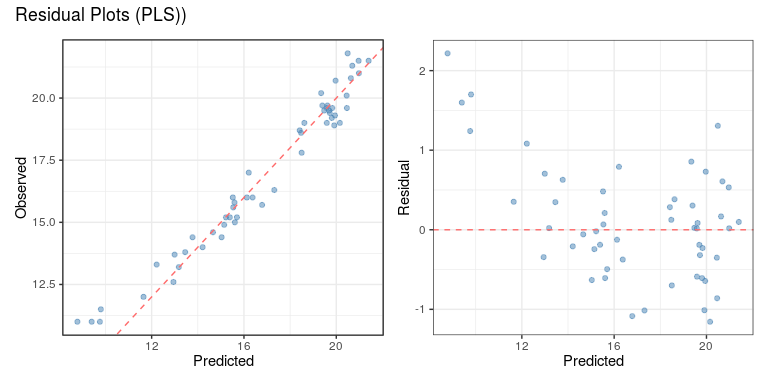

```r
preds <- pls_fit_final %>%
  collect_predictions() %>%
  mutate(residual = y - .pred)

p3 <- ggplot(preds) +
  geom_point(aes(.pred, y),
             color = "steelblue", alpha = 0.5) +
  geom_abline(color = "indianred1", linetype = "dashed") +
  labs(x = "Predicted", y = "Observed")

p4 <- ggplot(preds) +
  geom_point(aes(.pred, residual),
             color = "steelblue", alpha = 0.5) +
  geom_hline(yintercept = 0,
             color = "indianred1", linetype = "dashed") +
  labs(x = "Predicted", y = "Residual")

p3 + p4 + plot_annotation(title = "Residual Plots (PLS))")
```

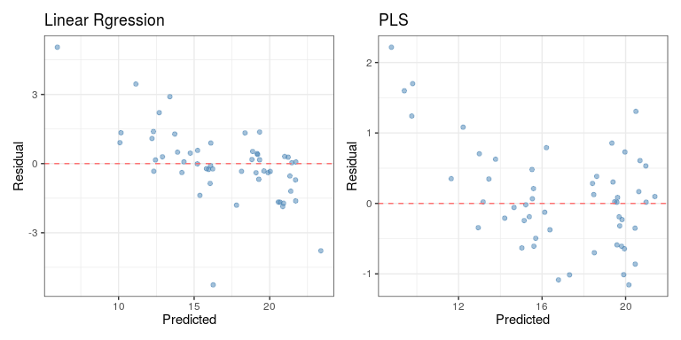

```r
p2.2 <- p2 + ggtitle("Linear Rgression")
p4.2 <- p4 + ggtitle("PLS")
p2.2 + p4.2
```

## Ridge Regregression

### Training Data

Build a ridge regression model and train using cross-validation.

```r
# Recipe:
rec3 <-
  recipe(y ~ ., data = df_train) %>%
  step_center(all_predictors()) %>%
  step_scale(all_predictors())

# Model:
# We will use tune() to find the `penalty` value. Setting `mixture` to 0 gives ridge regression.
rr_mod <-
  linear_reg(penalty = tune(), mixture = 0) %>%
  set_mode("regression") %>%
  set_engine("glmnet")

# Workflow:
workflow3 <-
  workflow() %>%
  add_model(spec = rr_mod) %>%
  add_recipe(recipe = rec3)

# Tuning grid:
rr_grid <- tibble(penalty = 10^seq(-4, 0, length.out = 25))

# Use `tune::tune_grid()` to combine the workflow and CV folds to fit the model on the training data:
## Read in cached results if available:
file1 <- "/home/brian/R/dir/APM/chapter6/models/rr_cv_6.1.RDS"
if (file.exists(file1)) {
  rr_cv <- readRDS(file1)
} else {
  rr_cv <-
    workflow3 %>%
    tune_grid(resamples = folds,
              grid = rr_grid,
              control = control_grid(save_pred = TRUE),
              metrics = metric_set(rmse, rsq))
  saveRDS(rr_cv, file1)
}
```

Plot CV results:

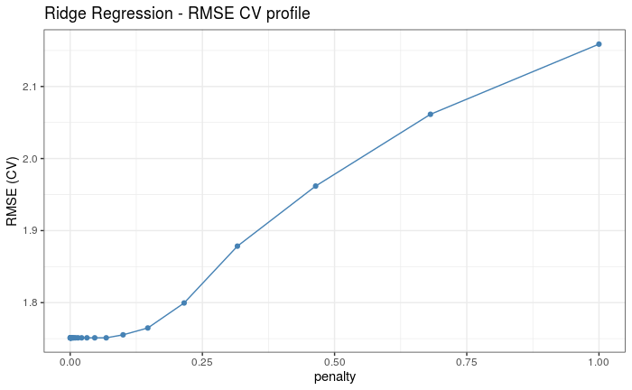

```r
rr_cv %>%
  collect_metrics() %>%
  filter(.metric == "rmse") %>%
  ggplot(aes(penalty, mean)) +
  geom_point(color = "steelblue") +
  geom_line(color = "steelblue") +
  labs(y = "RMSE (CV)", title = "Ridge Regression - RMSE CV profile")
```

The error is constant for low values of `penalty` before increasing for larger values.

Select the best model and store the training error:

```r
rr_best <- rr_cv %>%
  select_best("rmse")

# Store the training error:
rmse_train <- rr_cv %>%
  show_best("rmse") %>%
  pluck("mean", 1)
```

### Testing Data

Fit a model using all of the training data and apply it to the test data:

```r
# Finalize the workflow by updating it to use the best model:
final_wf <-
  workflow3 %>%
  finalize_workflow(rr_best)

# This extracts the parameters in the final model (this code is clunky, could probably be made simpler):
wf <- final_wf %>% workflows::pull_workflow_spec()
penalty <- wf$args$penalty[2] %>% as.character()

# Fit the final model using all of the training data and evaluate using the test data:
rr_fit_final <-
  final_wf %>%
  last_fit(splits)

# Store test error:
rmse_test <- rr_fit_final %>%
  collect_metrics() %>%
  filter(.metric == "rmse") %>%
  pluck(".estimate")
```

Store the training and test RMSE values and parameters:

```r
RMSE_TM <- rbind(RMSE_TM,
                 c(framework = "tidymodels",
                   engine = "glmnet",
                   model = "Ridge Regression",
                   rmse_train = rmse_train,
                   rmse_test = rmse_test,
                   parameters = str_interp("penalty: ${penalty}")))
```

### Use the predictions to make diagnostic plots

Collect the predictions from the final fit and make diagnostic plots:

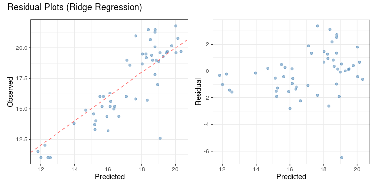

```r
preds <- rr_fit_final %>%
  collect_predictions() %>%
  mutate(residual = y - .pred)

p5 <- ggplot(preds) +
  geom_point(aes(.pred, y),
             color = "steelblue", alpha = 0.5) +
  geom_abline(color = "indianred1", linetype = "dashed") +
  labs(x = "Predicted", y = "Observed")

p6 <- ggplot(preds) +
  geom_point(aes(.pred, residual),
             color = "steelblue", alpha = 0.5) +
  geom_hline(yintercept = 0,
             color = "indianred1", linetype = "dashed") +
  labs(x = "Predicted", y = "Residual")

p5 + p6 + plot_annotation(title = "Residual Plots (Ridge Regression)")
```

There is not much pattern in the residuals.

## Lasso

### Training Data

Build a lasso model and train using cross-validation.

```r
# Recipe:
rec4 <-
  recipe(y ~ ., data = df_train) %>%
  step_center(all_predictors()) %>%
  step_scale(all_predictors())

# Model:
# We will use tune() to find the `penalty` value. Setting `mixture` to 1 gives lasso.
lasso_mod <-
  linear_reg(penalty = tune(), mixture = 1) %>%
  set_mode("regression") %>%
  set_engine("glmnet")

# Workflow:
workflow4 <-
  workflow() %>%
  add_model(spec = lasso_mod) %>%
  add_recipe(recipe = rec4)

# Tuning grid:
lasso_grid <- tibble(penalty = 10^seq(-4, 0, length.out = 25))

# Use `tune::tune_grid()` to combine the workflow and CV folds to fit the model on the training data:
## Read in cached results if available:
file1 <- "/home/brian/R/dir/APM/chapter6/models/lasso_cv_6.1.RDS"
if (file.exists(file1)) {
  lasso_cv <- readRDS(file1)
} else {
  lasso_cv <-
    workflow4 %>%
    tune_grid(resamples = folds,
              grid = lasso_grid,
              control = control_grid(save_pred = TRUE),
              metrics = metric_set(rmse, rsq))
  saveRDS(lasso_cv, file1)
}
```

Plot CV results:

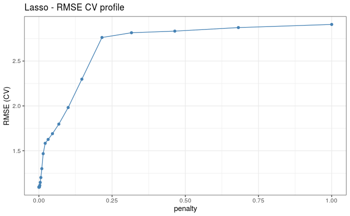

```r
lasso_cv %>%
  collect_metrics() %>%
  filter(.metric == "rmse") %>%
  ggplot(aes(penalty, mean)) +
  geom_point(color = "steelblue") +
  geom_line(color = "steelblue") +
  labs(y = "RMSE (CV)", title = "Lasso - RMSE CV profile")
```

Select the best model and store the training error:

```r
lasso_best <- lasso_cv %>%
  select_best("rmse")

# Store the training error:
rmse_train <- lasso_cv %>%
  show_best("rmse") %>%
  pluck("mean", 1)
```

### Testing Data

Fit a model using all of the training data and apply it to the test data:

```r
# Finalize the workflow by updating it to use the best model:
final_wf <-
  workflow4 %>%
  finalize_workflow(lasso_best)

# This extracts the parameters in the final model (this code is clunky, could probably be made simpler):
wf <- final_wf %>% workflows::pull_workflow_spec()
penalty <- wf$args$penalty[2] %>% as.character()

# Fit the final model using all of the training data and evaluate using the test data:
lasso_fit_final <-
  final_wf %>%
  last_fit(splits)

# Store test error:
rmse_test <- lasso_fit_final %>%
  collect_metrics() %>%
  filter(.metric == "rmse") %>%
  pluck(".estimate")
```

Store the training and test RMSE values and parameters:

```r
RMSE_TM <- rbind(RMSE_TM,
                 c(framework = "tidymodels",
                   engine = "glmnet",
                   model = "Lasso",
                   rmse_train = rmse_train,
                   rmse_test = rmse_test,
                   parameters = str_interp("penalty: ${penalty}")))
```

### Use the predictions to make diagnostic plots

Collect the predictions from the final fit and make diagnostic plots:

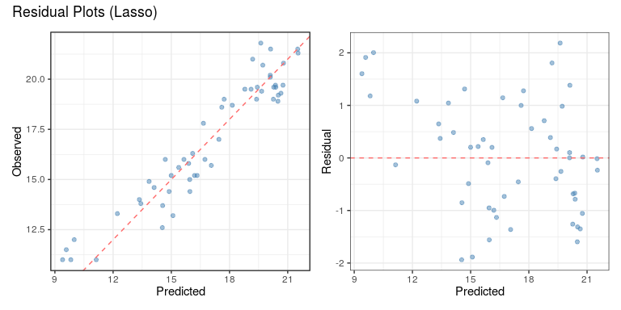

```r
preds <- lasso_fit_final %>%
  collect_predictions() %>%
  mutate(residual = y - .pred)

p7 <- ggplot(preds) +
  geom_point(aes(.pred, y),
             color = "steelblue", alpha = 0.5) +
  geom_abline(color = "indianred1", linetype = "dashed") +
  labs(x = "Predicted", y = "Observed")

p8 <- ggplot(preds) +
  geom_point(aes(.pred, residual),
             color = "steelblue", alpha = 0.5) +
  geom_hline(yintercept = 0,
             color = "indianred1", linetype = "dashed") +
  labs(x = "Predicted", y = "Residual")

p7 + p8 + plot_annotation(title = "Residual Plots (Lasso)")
```

There is not much pattern in the residuals.

## Elastic Net

### Training Data

Build an elastic net model and train using cross-validation.

```r
# Recipe:
rec5 <-
  recipe(y ~ ., data = df_train) %>%
  step_center(all_predictors()) %>%
  step_scale(all_predictors())

# Model:
# We will use tune() to find the `penalty` and `mixture` values.
enet_mod <-
  linear_reg(penalty = tune(), mixture = tune()) %>%
  set_mode("regression") %>%
  set_engine("glmnet")

# Workflow:
workflow5 <-
  workflow() %>%
  add_model(spec = enet_mod) %>%
  add_recipe(recipe = rec5)

# Tuning grid:
enet_grid <- expand_grid(penalty = c(0, 0.001, 0.01, 0.1, 1),
                         mixture = seq(0.05, 1, length = 20))

# Use `tune::tune_grid()` to combine the workflow and CV folds to fit the model on the training data:
## Read in cached results if available:
file1 <- "/home/brian/R/dir/APM/chapter6/models/enet_cv_6.1.RDS"
if (file.exists(file1)) {
  enet_cv <- readRDS(file1)
} else {
  enet_cv <-
    workflow5 %>%
    tune_grid(resamples = folds,
              grid = enet_grid,
              control = control_grid(save_pred = TRUE),
              metrics = metric_set(rmse, rsq))
  saveRDS(enet_cv, file1)
}
```

Plot CV results:

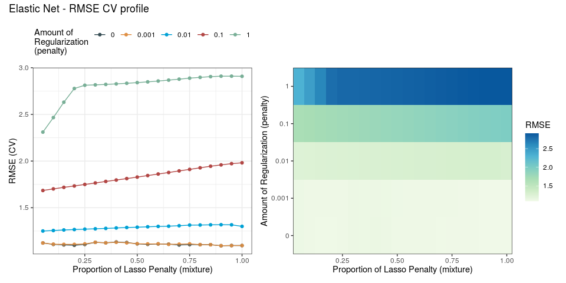

```r
p1 <- enet_cv %>%
  collect_metrics() %>%
  filter(.metric == "rmse") %>%
  mutate(penalty = factor(penalty)) %>%
  ggplot(aes(mixture, mean, color = penalty)) +
  geom_point() +
  geom_line() +
  labs(x = "Proportion of Lasso Penalty (mixture)", y = "RMSE (CV)", color = "Amount of\nRegularization\n(penalty)") +
  ggsci::scale_color_jama() +
  theme(legend.position = "top")

p2 <- enet_cv %>%
  collect_metrics() %>%
  filter(.metric == "rmse") %>%
  mutate(penalty = factor(penalty)) %>%
  ggplot(aes(mixture, penalty, fill = mean)) +
  geom_raster() +
  labs(x = "Proportion of Lasso Penalty (mixture)", y = "Amount of Regularization (penalty)") +
  scale_fill_distiller(name = "RMSE", palette = 4, direction = "reverse") +
  coord_cartesian(expand = FALSE)

p1 + p2 + plot_annotation(title = "Elastic Net - RMSE CV profile")
```

For a given value of `penalty`, the error is relatively constant across all values of `mixture`. The error tends to be lower for lower values of `penalty`.

Select the best model and store the training error:

```r
enet_best <- enet_cv %>%
  select_best("rmse")

# Store the training error:
rmse_train <- enet_cv %>%
  show_best("rmse") %>%
  pluck("mean", 1)
```

### Testing Data

Fit a model using all of the training data and apply it to the test data:

```r
# Finalize the workflow by updating it to use the best model:
final_wf <-
  workflow5 %>%
  finalize_workflow(enet_best)

# This extracts the parameters in the final model (this code is clunky, could probably be made simpler):
wf <- final_wf %>% workflows::pull_workflow_spec()
penalty <- wf$args$penalty[2] %>% as.character()
mixture <- wf$args$mixture[2] %>% as.character()

# Fit the final model using all of the training data and evaluate using the test data:
enet_fit_final <-
  final_wf %>%
  last_fit(splits)

# Store test error:
rmse_test <- enet_fit_final %>%
  collect_metrics() %>%
  filter(.metric == "rmse") %>%
  pluck(".estimate")
```

Store the training and test RMSE values and parameters:

```r
RMSE_TM <- rbind(RMSE_TM,
                 c(framework = "tidymodels",
                   engine = "glmnet",
                   model = "Elastic Net",
                   rmse_train = rmse_train,
                   rmse_test = rmse_test,
                   parameters = str_interp("penalty: ${penalty}; mixture: ${mixture}")))
```

### Use the predictions to make diagnostic plots

Collect the predictions from the final fit and make diagnostic plots:

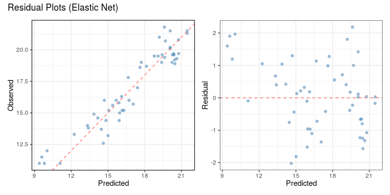

```r
preds <- enet_fit_final %>%
  collect_predictions() %>%
  mutate(residual = y - .pred)

p9 <- ggplot(preds) +
  geom_point(aes(.pred, y),
             color = "steelblue", alpha = 0.5) +
  geom_abline(color = "indianred1", linetype = "dashed") +
  labs(x = "Predicted", y = "Observed")

p10 <- ggplot(preds) +
  geom_point(aes(.pred, residual),
             color = "steelblue", alpha = 0.5) +
  geom_hline(yintercept = 0,
             color = "indianred1", linetype = "dashed") +
  labs(x = "Predicted", y = "Residual")

p9 + p10 + plot_annotation(title = "Residual Plots (Elastic Net)")
```

Not much pattern in the residuals.

# (d)

## Metrics

Order the models by performance on the test data:

```r
RMSE_TM %>%
  mutate(rmse_train = round(as.numeric(rmse_train), 3),
         rmse_test = round(as.numeric(rmse_test), 3)) %>%
  arrange(rmse_test)
```

| framework | engine | model | rmse_train | rmse_test | parameters |
| --- | --- | --- | --- | --- | --- |
| tidymodels | mixOmics | PLS | 0.625 | 0.724 | num_comp: 14 |
| tidymodels | lm | PCR | 0.754 | 0.772 | num_comp: 25 |
| tidymodels | glmnet | Elastic Net | 1.093 | 1.051 | penalty: 0; mixture: 0.9 |
| tidymodels | glmnet | Lasso | 1.095 | 1.061 | penalty: 1e-04 |
| tidymodels | lm | Linear Regression | 1.079 | 1.570 | NA |
| tidymodels | glmnet | Ridge Regression | 1.751 | 1.676 | penalty: 1e-04 |

PLS performs best, with PCR in second. The linear regression and ridge regression models perform much worse than the others.

# (e)

The PLS model is the best option as it had the best test error and is especially suited to handling highly correlated data. PCR also performs well, but PLS takes into account the correlation of the predictors with the response making this supervised approach suitable for regression.

*Note:* It seems strange that the ridge regression model is worse than linear regression. This is likely due to the difference in engines being used (`lm` vs `glmnet`). See the rough work notebook where I redo linear regression using the `glmnet` package. This time the error is the same as the ridge regression model, but since the penalty is zero in that model it is just linear regression. However, now that the engines are the same we get the same result. The result for linear regression should be the same regardless of the engine, but the high multi-collinearity is likely causing the inconsistent results.

[^1]: Kuhn M, Johnson K (2013). *Applied Predictive Modeling*. Springer.